# Análisis de correspondencias

## El análisis de correspondencias

La función `CA` del paquete `FactoMiner` es una de las muchas que podemos emplear.

> CA(X, ncp = 5, graph = TRUE)

siendo

- X un data frame (la tabla de contingencia);
- ncp el número de dimensiones que se emplearán en la solución final;
- graph hace referencia a la presentación (si `TRUE`) del gráfico de asociación.

Hacemos una primera aproximación a esta función, para comprobar los elementos que incluye el objeto tipo lista que se genera:

```r
votos.ca=CA(tabla.votos, graph = FALSE)
votos.ca
```

```
**Results of the Correspondence Analysis (CA)**
The row variable has  5  categories; the column variable has 5 categories
The chi square of independence between the two variables is equal to 1704.298 (p-value =  0 ).
*The results are available in the following objects:

   name              description
1  "$eig"            "eigenvalues"
2  "$col"            "results for the columns"
3  "$col$coord"      "coord. for the columns"
4  "$col$cos2"       "cos2 for the columns"
5  "$col$contrib"    "contributions of the columns"
6  "$row"            "results for the rows"
7  "$row$coord"      "coord. for the rows"
8  "$row$cos2"       "cos2 for the rows"
9  "$row$contrib"    "contributions of the rows"
10 "$call"           "summary called parameters"
11 "$call$marge.col" "weights of the columns"
12 "$call$marge.row" "weights of the rows"
```

Por ejemplo, podemos ver un resumen del análisis efectuado mediante la función `summary`:

> summary(object, nb.dec = 3, nbelements = 10, ncp = TRUE, file =“”, …)
- object: el objeto de clase CA que habremos generado;
- nb.dec: número de decimales en la salida;
- nbelements: número de variables de fila/columna a presentar; si queremos todos los elementos, haremos `nbelements = Inf`;
- ncp: número de dimensiones presentadas;
- file: opcional; nombre del archivo para grabar el resumen.

Así, si queremos el resumen de las dos primeras dimensiones del análisis,

```r
summary(votos.ca, nb.dec = 2, ncp = 2)
```

```
Call:
CA(X = tabla.votos, graph = FALSE)

The chi square of independence between the two variables is equal to 1704.298 (p-value =  0 ).

Eigenvalues
                      Dim.1  Dim.2  Dim.3  Dim.4
Variance               0.09   0.04   0.02   0.00
% of var.             64.65  24.45  10.79   0.11
Cumulative % of var.  64.65  89.10  99.89 100.00

Rows
             Iner*1000   Dim.1   ctr  cos2   Dim.2   ctr  cos2
Trabaja    |      7.86 |  0.14  4.33  0.52 |  0.13  9.20  0.42 |
Domestico  |     30.66 | -0.30 18.80  0.58 | -0.18 17.11  0.20 |
Parado     |     19.47 |  0.09  1.61  0.08 |  0.29 45.65  0.84 |
Estudiante |     51.85 |  0.46 43.70  0.80 | -0.22 27.90  0.19 |
Jubilado   |     36.95 | -0.39 31.56  0.81 | -0.02  0.14  0.00 |

Columns
             Iner*1000   Dim.1   ctr  cos2   Dim.2   ctr  cos2
PP         |     28.84 | -0.30 20.77  0.68 | -0.01  0.03  0.00 |
PSOE       |     21.35 | -0.25 16.35  0.73 | -0.06  2.41  0.04 |
UP         |     40.90 |  0.39 23.25  0.54 |  0.36 52.25  0.46 |
Cs         |      2.45 | -0.02  0.13  0.05 |  0.06  2.05  0.30 |
Resto      |     53.25 |  0.49 39.51  0.70 | -0.32 43.26  0.29 |
```

Antes de pasar a la interpretación, podemos señalar que la función `summary()` devuelve el resultado del test de independencia que previamente habíamos efectuado junto con 3 tablas:

- Una primera tabla de **autovalores**, con las varianzas de cada dimensión y el poder explicativo de cada una de ellas;
- Una segunda con las coordenadas, la contribución y el $cos^2$ o calidad de la representación en $[0;1]$ de las primeras 10 categorías de fila activas en las dimensiones 1 y 2;
- Y una tercera con la misma información relativa a las categorías de columna.

### Interpretación de los resultados del análisis

Interpretar la solución del *CA* requiere identificar dónde se encuentran las relaciones significativas entre filas y columnas. Existen dos vías para inspeccionar lo significativo de esa relación:

- Mediante la **traza**, que no es sino la *inercia* total de la tabla (esto es, la suma de sus autovalores); su raíz cuadrada se interpreta como el coeficiente de correlación entre filas y columnas;
- mediante el estadístico **chi cuadrado** del test de independencia, una vía más rigurosa; como hemos visto, tal y como ofrece la propia función `summary()`, su resultado igual a 1704.3 con un nivel de significación o *p*-valor de 0 señala con claridad la existencia de relaciones entre categorías de fila y de columna.

Volviendo sobre la traza y la correlación entre filas y columnas, podemos proceder a calcularlo de forma sencilla como sigue:

```r
eig = get_eigenvalue(votos.ca)
traza = sum(eig[1:4])
coef.cor = sqrt(traza)
coef.cor
```

```
[1] 0.3831393
```

De forma general, se admite que un coeficiente de correlación por encima de $0.2$ es significativo de asociación entre las categorías, de forma que aquí tendríamos una confirmación alternativa.

Por otro lado, podemos comprobar que el producto de la traza por el número total de observaciones nos devuelve el valor del estadístico $\chi^2_0$, que el número de grados de libertad se corresponde con el producto del número de filas menos una por el número de columnas menos una y que, entonces, el nivel de significación o *p*-valor se corresponde con $P(\chi^2_{(f-1)(c-1)} > \chi^2_0)$

```r
chi2 = traza*sum(as.matrix(votos.def))
chi2
```

```
[1] 1704.298
```

```r
gdl=(nrow(votos.def) - 1) * (ncol(votos.def) - 1)
gdl
```

```
[1] 16
```

```r
p.val = pchisq(chi2, df = gdl, lower.tail = FALSE)
p.val
```

```
[1] 0
```

### Identificaciónn del número de dimensiones a retener

Como ocurría en el análisis factorial y en el de componentes principales, uno de los principales problemas a resolver es el de la correcta reducción de las dimensiones; en este caso, también, emplearemos como regla de decisión el tanto por ciento de la varianza explicada (regla de Kaiser en el factorial). Siendo la traza la inercia o varianza total del sistema, la inercia de un eje no es sino la proporción de su autovalor (o varianza, o chi cuadrado) respecto de la traza. Esa información la obtenemos del objeto de clase *CA* obtenido previamente:

```r
round(votos.ca$eig, 2)
```

```
      eigenvalue percentage of variance cumulative percentage of variance
dim 1       0.09                  64.65                             64.65
dim 2       0.04                  24.45                             89.10
dim 3       0.02                  10.79                             99.89
dim 4       0.00                   0.11                            100.00
```

En este caso, comprobamos cómo las dos primeras dimensiones retienen el $89\%$ de la varianza explicada, teniendo mucha más importancia la primera que la segunda.

Otra forma de actuar es aplicando el *screeplot* o gráfico de sedimentación que vimos en el análisis factorial. A partir de `factoextra`, podemos representarlo como sigue:

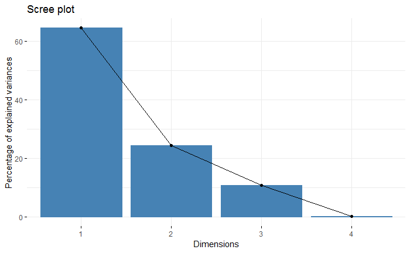

```r
fviz_screeplot(votos.ca)
```

La aplicación de la regla heurística del hombro nos llevaría a mantener sólo la primera dimensión; sin embargo, mantendremos las dos primeras a efectos de llevar a cabo la representación gráfica de los puntos de fila y de columna. Podríamos añadir una línea que representase el límite teórico requerido para la contribución de un eje, y, en ese sentido, para mantenerlo en la solución final; dado que tenemos un total de 5 filas y 5 columnas, si las observaciones fuesen independientes, a cada una de las dimensiones le correspondería un total de $\dfrac{1}{f-1}=0.25$, en términos de filas, y otro tanto en términos de columnas. Por tanto, la información que aportaría cada eje en un sistema de variables independientes sería de aproximadamente un $25\%$. En este caso, y debido a contar con el mismo número de filas y columnas, usaremos ese porcentaje como el indicativo del mínimo poder informativo que debe aportar una dimensión. En general, será el mayor de los dos valores el que usaremos como indicador. Añadimos una línea a esa altura al gráfico anterior,

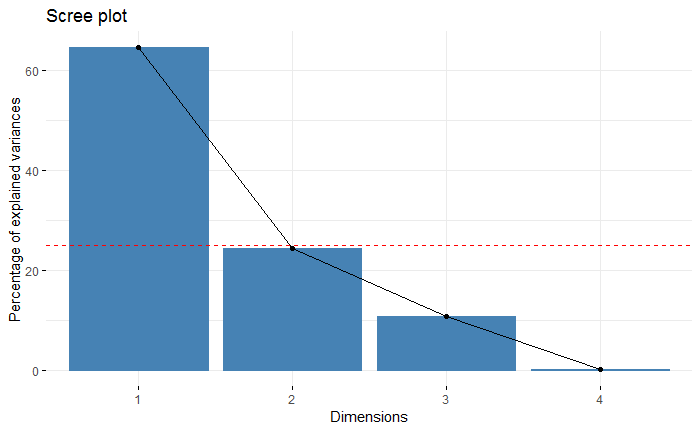

```r
fviz_screeplot(votos.ca) +
        geom_hline(yintercept=25, linetype=2, color="red")
```

### Representación gráfica

Mediante la función `plot` de `FactoMineR` podemos representar las coordenadas de las categorías en filas y columnas del *CA*.

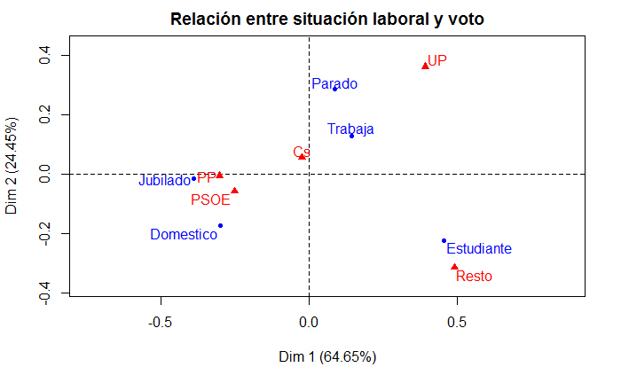

```r
plot(votos.ca, axes=c(1, 2), col.row = "blue", col.col ="red", title = "Relación entre situación laboral y voto")
```

También podemos efectuar una representación análoga mediante la función `fviz_ca_biplot` de `factoextra`:

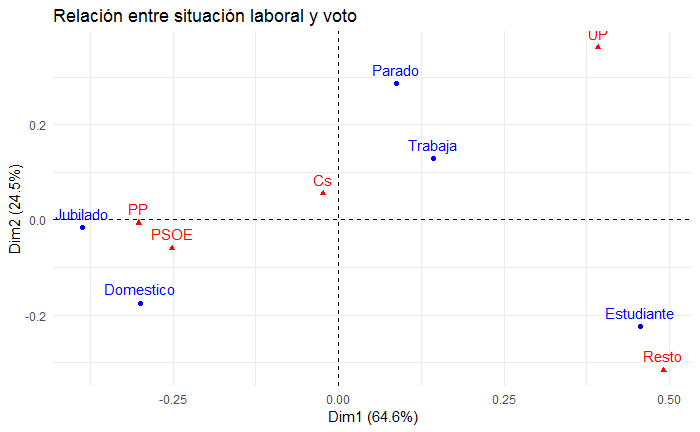

```r
fviz_ca_biplot(votos.ca) +
        ggtitle("Relación entre situación laboral y voto")+
        theme_minimal()
```

En cualquiera de las dos representaciones, la interpretación es la misma: la distancia entre puntos de distinto eje da cuenta de su similaridad, o de su disimilaridad. Así, podemos observar cómo el PP es más apreciado por los jubilados, mientras que quienes se relacionan con las tareas del hogar (trabajo no remunerado en casa) son más seguidores del PSOE, y los estudiantes del *resto* de fuerzas políticas. Ciudadanos se asociaría más a los trabajadores mientras que los parados, más a UP.

### Contribución de filas y columnas

La siguiente fase del *CA* tiene que ver con la identificación de las categorías de filas y de columnas que más ayudan en la explicación de las dimensiones del espacio factorial. La función `get_ca_row`lo hará respecto de las primeras mientras que `get_ca_col` lo hará respecto de las segundas.

```r
filas=get_ca_row(votos.ca)
filas
```

```
Correspondence Analysis - Results for rows
 ===================================================
  Name       Description
1 "$coord"   "Coordinates for the rows"
2 "$cos2"    "Cos2 for the rows"
3 "$contrib" "contributions of the rows"
4 "$inertia" "Inertia of the rows"
```

Como podemos observar, la función nos da información de las coordenadas, el $cos^2$, la contribución y la inercia de las filas, como del mismo modo ocurrirá cuando lo solicitemos respecto de las columnas.

En cuanto a las coordenadas de las categorías de las filas, y sólo para las dos dimensiones representadas,

```r
filas$coord[, 1:2]
```

```
                 Dim 1       Dim 2
Trabaja     0.14337810  0.12854341
Domestico  -0.29866192 -0.17521276
Parado      0.08743675  0.28611185
Estudiante  0.45556525 -0.22387279
Jubilado   -0.38671622 -0.01582245
```

Podemos representar estas categorías aisladas de las correspondientes a las columnas del siguiente modo:

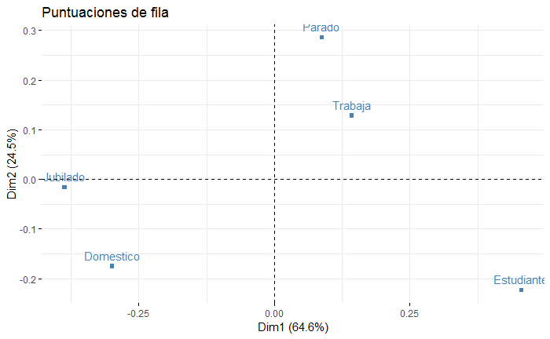

```r
fviz_ca_row(votos.ca, col.row="steelblue", shape.row = 15)+
        ggtitle("Puntuaciones de fila")
```

Este mismo resultado lo podíamos haber alcanzado “invisibilizando” las puntuaciones de las columnas en el gráfico base del *CA*:

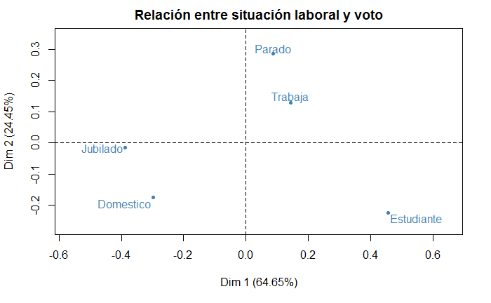

```r
plot(votos.ca, axes=c(1, 2), col.row = "steelblue", col.col ="red", title = "Relación entre situación laboral y voto",
     invisible = "col")
```

En cuanto a la contribución de las filas a la explicación de las dimensiones, dada en tanto por ciento, la obtenemos como

```r
filas$contrib
```

```
               Dim 1      Dim 2     Dim 3     Dim 4
Trabaja     4.326948  9.1954695  2.155071 64.348351
Domestico  18.799106 17.1067366 42.176704  1.917453
Parado      1.612647 45.6542607  9.582616 23.133250
Estudiante 43.702314 27.9038500  2.248948  6.162114
Jubilado   31.558984  0.1396832 43.836661  4.438832
```

Es interesante observar cómo son los estudiantes y los jubilados quienes más contribuyen a la explicación de esta dimensión 1, mientras que los parados lo son respecto de la segunda; y cómo quienes trabajan y quienes se dedican a las tareas del hogar definen mucho mejor las dimensiones 4 y 3, respectivamente. En todo caso, podemos efectuar un gráfico de correlaciones para observar esta relación:

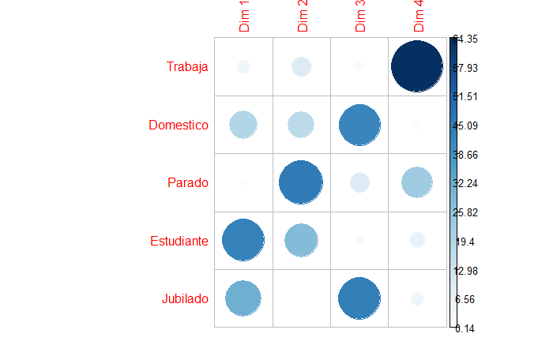

```r
library(corrplot)
corrplot(filas$contrib, is.corr = FALSE)
```

Respecto de las dos primeras dimensiones,

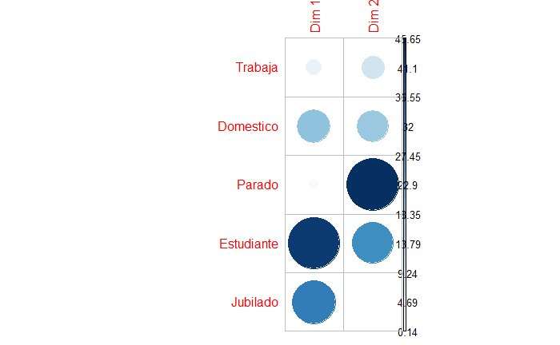

```r
corrplot(filas$contrib[, 1:2], is.corr = FALSE)
```

Mediante `fviz_contrib` podemos observar la contribución de las categorías de fila a la explicación de cada dimensión, en forma de gráfico de barras:

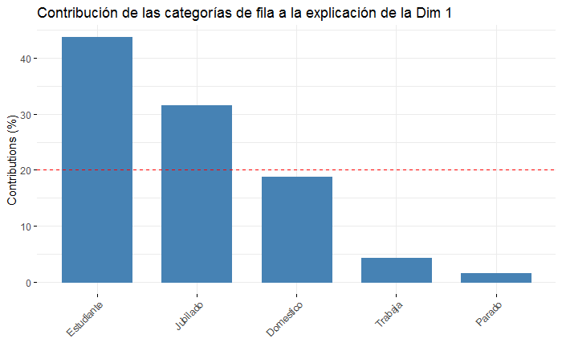

```r
fviz_contrib(votos.ca, choice = "row", axes =1)+
        ggtitle("Contribución de las categorías de fila a la explicación de la Dim 1")
```

La línea punteada en rojo ofrece la indicación de equicontribución bajo el supuesto de que las cinco aportase la misma información. Se observa cómo son los estudiantes quienes más informan de esta dimensión, como habíamos señalado.